# Drivers of sample number

### Sampling period

A note on sampling period. This is the time from the first activity in the project to the last sample collected and can be viewed as the sampling period. This was calculated by Ian.

### Country

We want to account for country in our model as it might be that people in one country sample more than another. This is not something we are interested in but is something we want to account for so we will keep it in the model as a random effect [this is no longer the case as I have to change to a model type that does not allow random effects, it is now included asa fixed effect]. The data was generated by Ian by taking the country that each user was trained in. Almost all users sample in a single country, which is the country that are trained in.

### Difficulty score

The difficulty score is the first axis of an PCA on a number of different metric that quantify the complexity of the tasks users do.

```r
# Let's do a pca of the difficulty metrics
PCA_d <- prcomp(~ Time + Bulk + Complex + Task,
             data = clean_data,
             center = TRUE,
             scale. = TRUE)

# The first axis explains 94% of the variance
summary(PCA_d)
```

```
## Importance of components:
##                          PC1     PC2     PC3     PC4
## Standard deviation     1.934 0.34125 0.32547 0.19417
## Proportion of Variance 0.935 0.02911 0.02648 0.00943
## Cumulative Proportion  0.935 0.96409 0.99057 1.00000
```

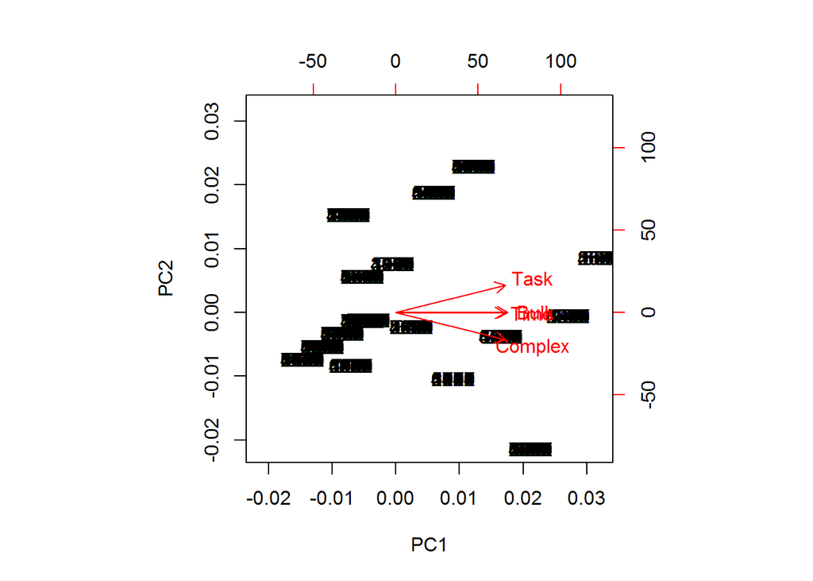

```r
# This is because the values are highly correlated
biplot(PCA_d)
```

```r
# add to our data
clean_data$difficulty_score <- PCA_d$x[,1]
```

It is important to note here that points are clustered together, this is because each protocol has a different difficulty but there are only 28 different protocols, and it look like some must share the same difficulty score. This is important to think about as the location and difficultly are likely to be correlated as a result.

### Group size

We are interested whether being in a larger group when you go out sampling means you are more likely to sample more due to a social factor. This is captured in the Particp variable.

### Looking at data for model

Staff have already been removed from this dataset (that is why there is no staff column this time).

```r
# At this point remove 0 samples
sample_data <- clean_data[clean_data$Sample > 0, ]

# How much data do we have for the covariates of interest?
nrow(sample_data)
```

```
## [1] 1510
```

```r
summary(sample_data[, c('PeriodSamp', 'Paid', 'difficulty_score', 'comm_cat', 'Team', 'Rainfall', 'Temp', 'Country', 'Particip')])
```

```
##    PeriodSamp          Paid        difficulty_score     comm_cat
##  Min.   : 249.0   Min.   :0.0000   Min.   :-2.4424   Min.   :0.0000
##  1st Qu.: 736.5   1st Qu.:0.0000   1st Qu.:-1.3928   1st Qu.:0.0000
##  Median : 989.0   Median :0.0000   Median :-0.8681   Median :0.0000
##  Mean   : 975.4   Mean   :0.3285   Mean   :-0.1795   Mean   :0.2344
##  3rd Qu.:1188.0   3rd Qu.:1.0000   3rd Qu.: 0.9943   3rd Qu.:0.0000
##  Max.   :1542.0   Max.   :1.0000   Max.   : 5.3241   Max.   :2.0000
##
##       Team           Rainfall             Temp           Country
##  Min.   :0.0000   Min.   :0.000000   Min.   :-17.59   Brazil :334
##  1st Qu.:1.0000   1st Qu.:0.000000   1st Qu.: 15.18   India  :195
##  Median :1.0000   Median :0.000927   Median : 20.96   UK     :183
##  Mean   :0.8589   Mean   :0.132211   Mean   : 19.50   China  :177
##  3rd Qu.:1.0000   3rd Qu.:0.170606   3rd Qu.: 24.98   Mexico :168
##  Max.   :1.0000   Max.   :3.168762   Max.   : 34.31   Canada :153
##                                                       (Other):300
##     Particip
##  Min.   : 0.000
##  1st Qu.: 1.000
##  Median : 2.000
##  Mean   : 3.098
##  3rd Qu.: 3.000
##  Max.   :40.000
##  NA's   :3
```

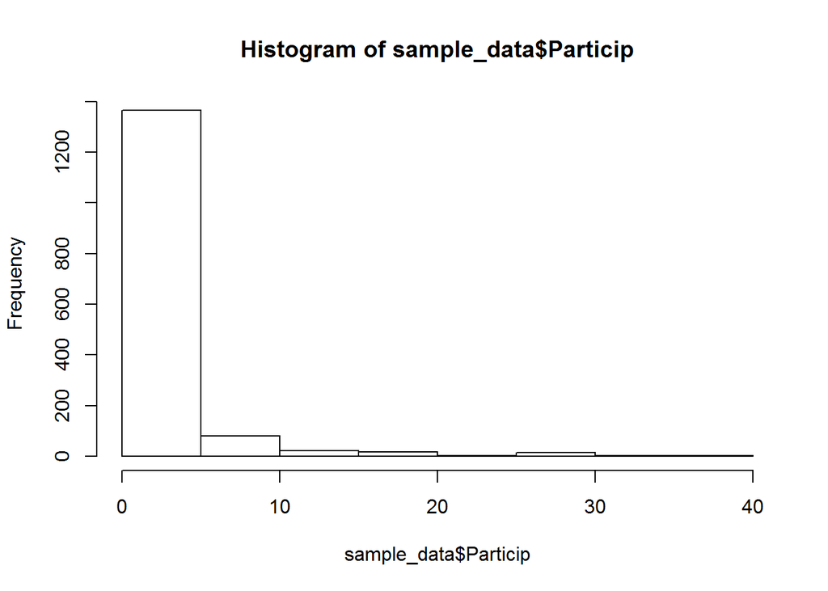

```r
# Could we add in the WQx variables? there are onl a handfull of NAs

# We might be best logging some of our predictor variables
hist(sample_data$Particip)
```

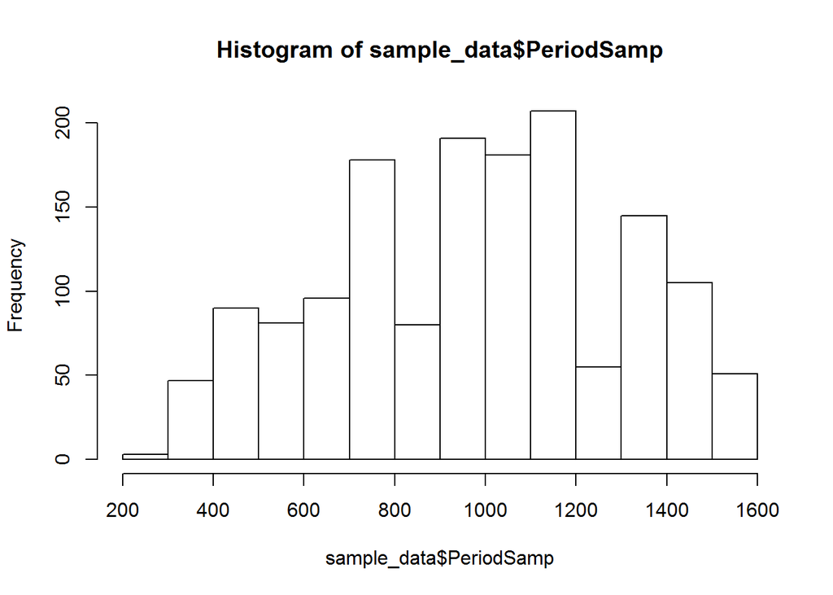

```r
hist(sample_data$PeriodSamp)
```

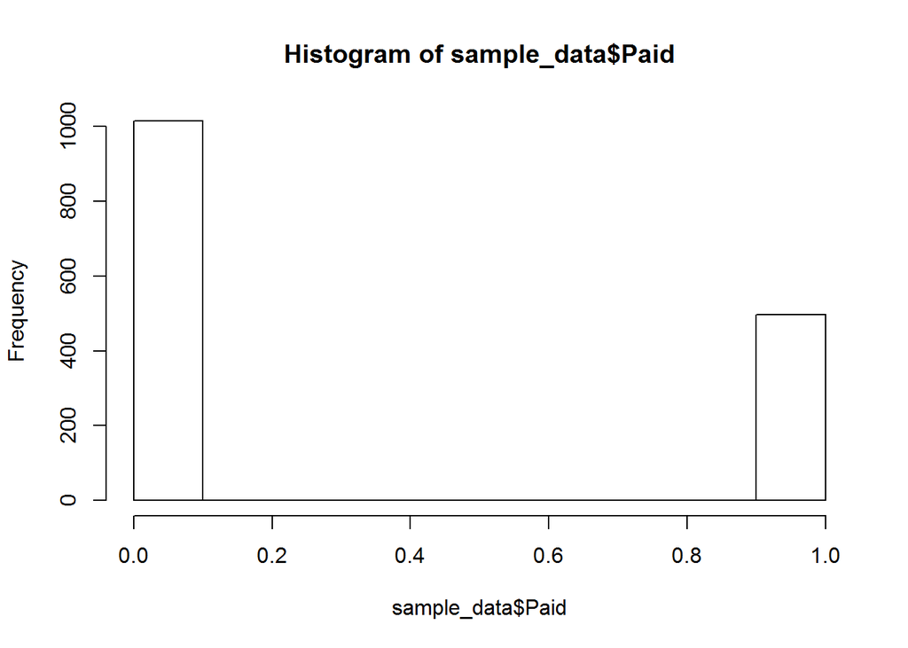

```r
hist(sample_data$Paid)
```

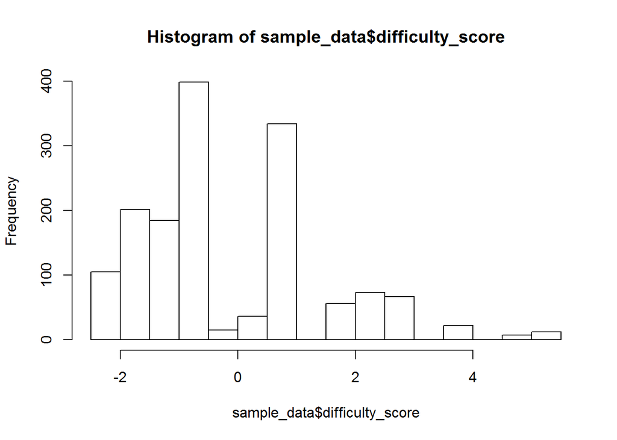

```r
hist(sample_data$difficulty_score)
```

```r
# hist(log(sample_data$difficulty_score))
# hist(log(sample_data$comm_score + 1))
table(sample_data$comm_cat)
```

```
##
##    0    1    2
## 1278  110  122
```

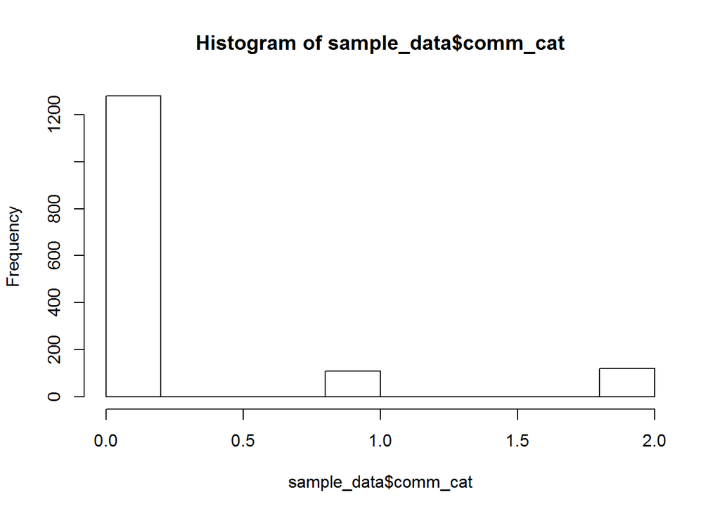

```r
hist(sample_data$comm_cat)
```

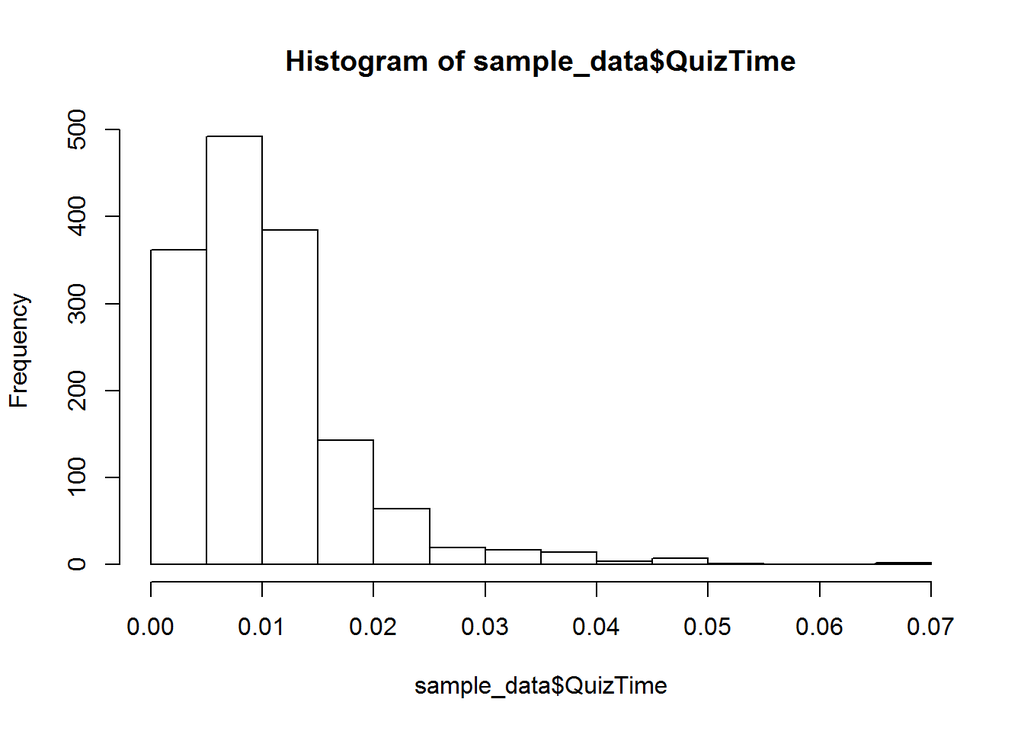

```r
hist(sample_data$QuizTime)
```

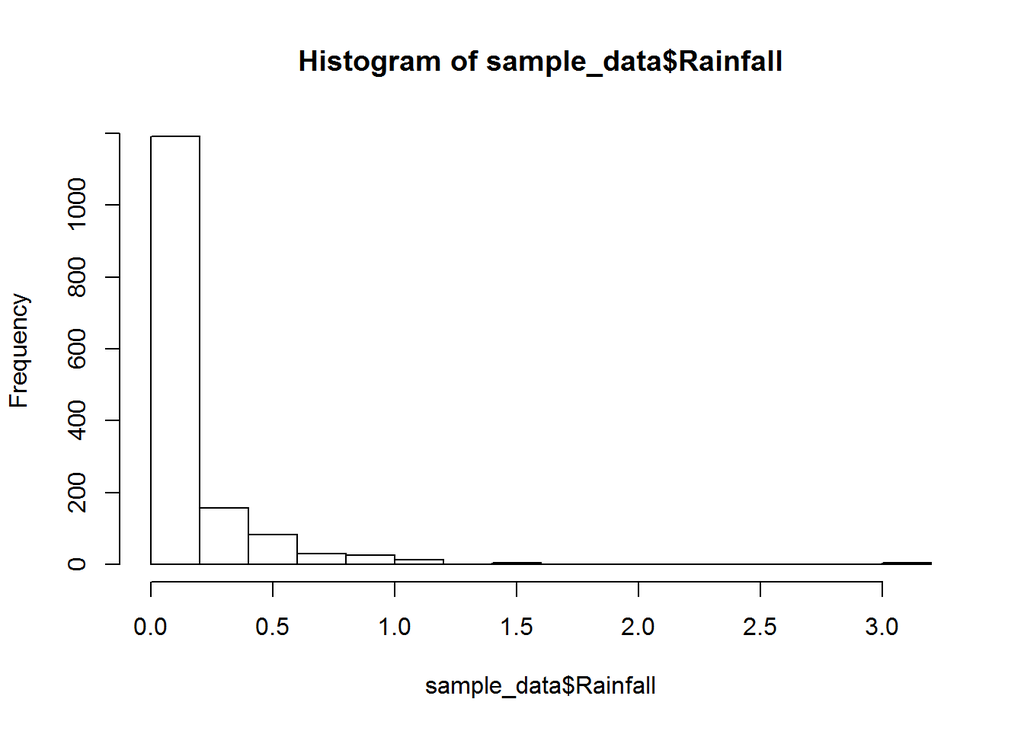

```r
hist(sample_data$Rainfall)
```

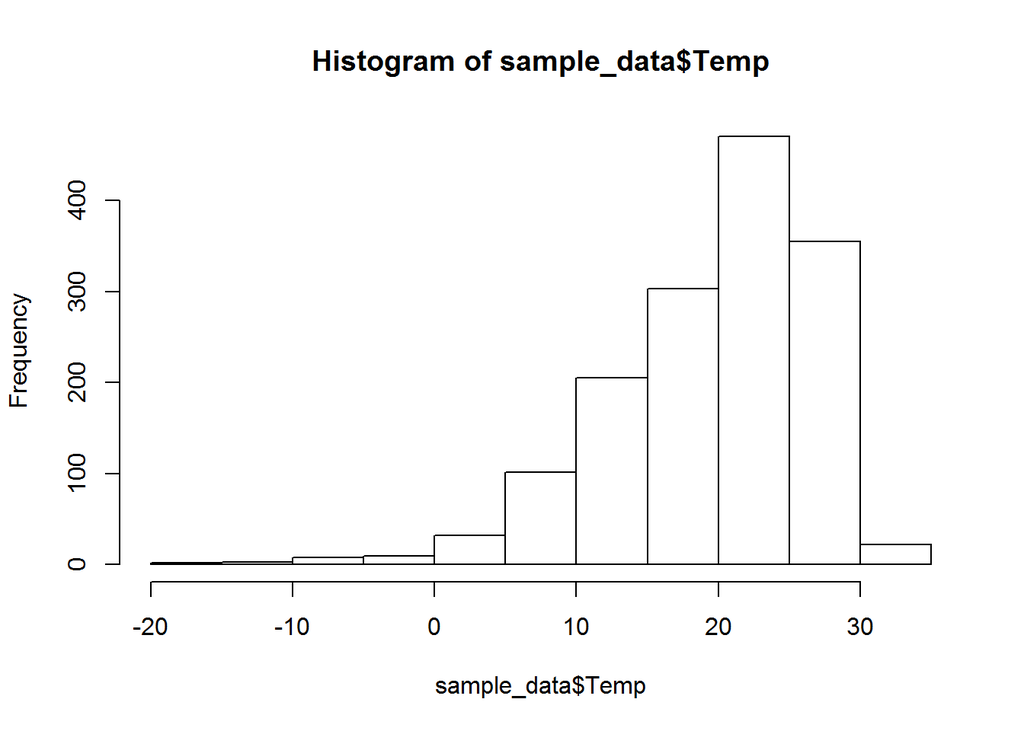

```r
hist(sample_data$Temp)
```

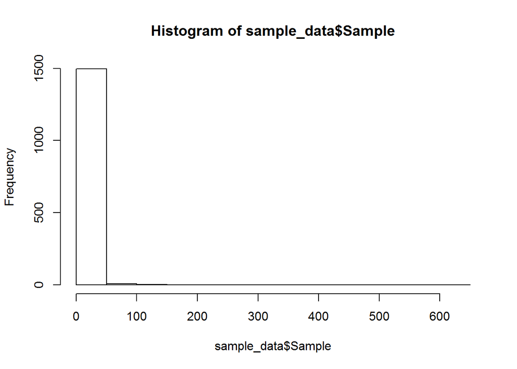

```r
hist(sample_data$Sample)
```

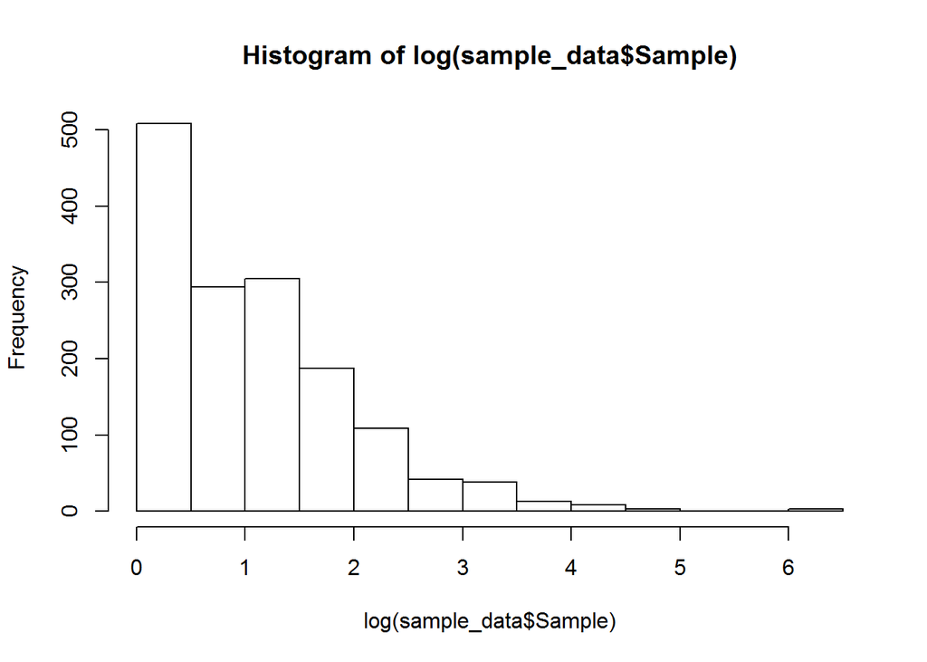

```r
hist(log(sample_data$Sample))
```

We can use a poisson distribution to account for the skew in the samples counts. We need to log the sample counts for this to work but this result in non-integer values which wont work with poission, instead we need to use quasi-poisson. In turn this means we cannot use a mixed effects model so we need to include country as a fixed efect.

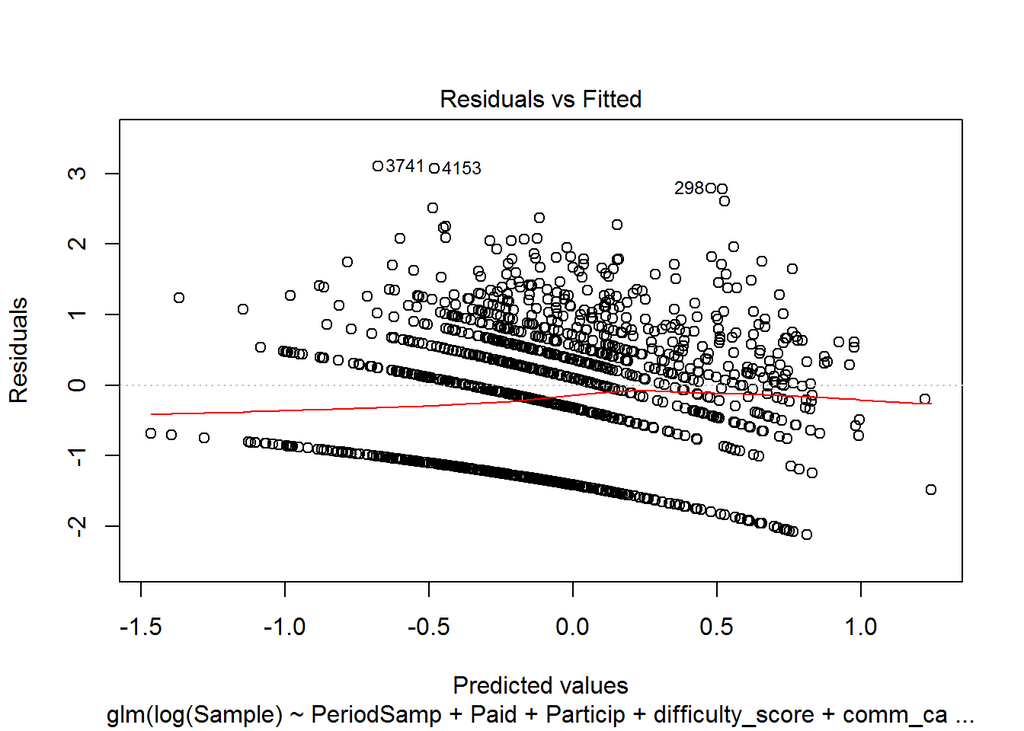

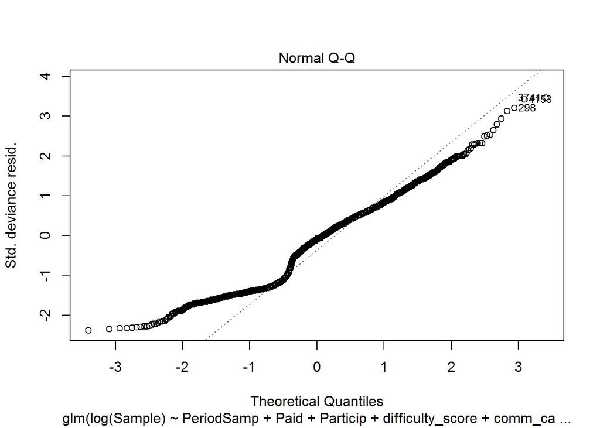

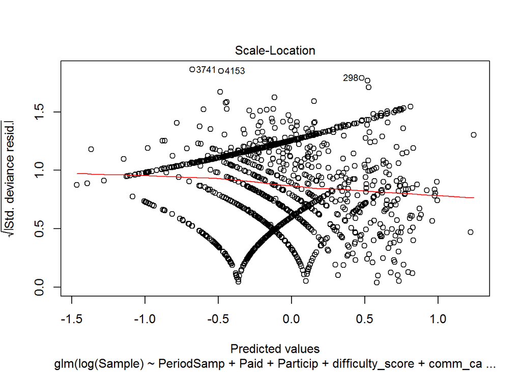

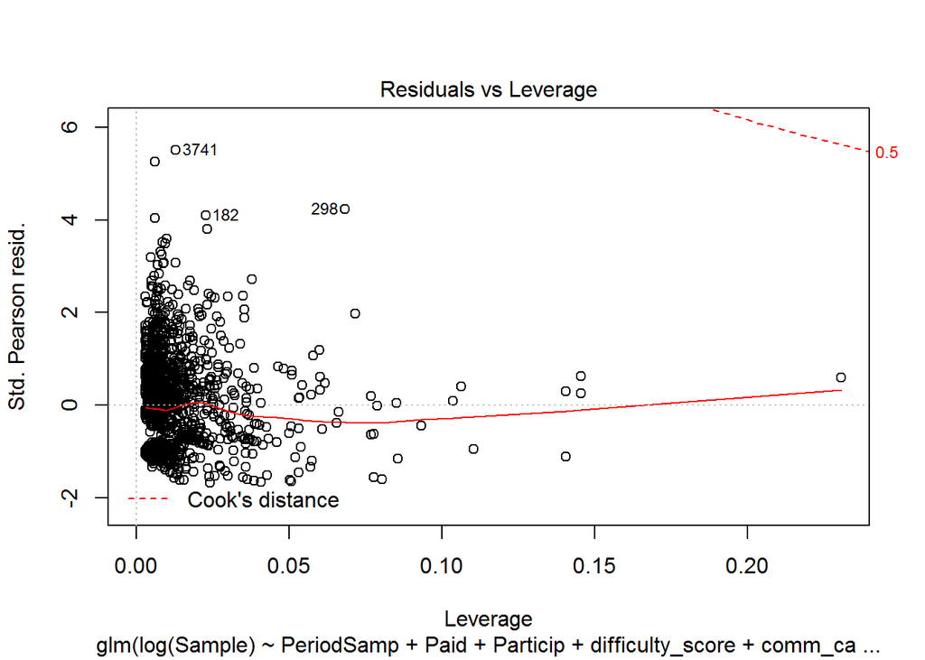

```r
# lets just add in country as a fixed effect here
m2a <- glm(log(Sample) ~ PeriodSamp +
                        Paid +
                        Particip +
                        difficulty_score +
                        comm_cat +
                        QuizTime +
                        # Team + # this has no effect on the model but fixes UK issue
                        # Rainfall + # I dont these climate variables should be here
                        # Temp + # do we really expect them to have an effect here?
                        Country,
            data = sample_data,
            family = quasipoisson)
plot(m2a, ask = FALSE)
```

```r
# the three outliers without log(samples) are the three people with the most samples
# We have 'zero-inflation' I think
# Negative binomial is not better
# zeroinflation model doesnt help
summary(m2a)
```

```
##
## Call:
## glm(formula = log(Sample) ~ PeriodSamp + Paid + Particip + difficulty_score +
##     comm_cat + QuizTime + Country, family = quasipoisson, data = sample_data)
##
## Deviance Residuals:
##      Min        1Q    Median        3Q       Max
## -2.12379  -1.14792  -0.07936   0.49184   3.10318
##
## Coefficients:
##                    Estimate Std. Error t value Pr(>|t|)
## (Intercept)      -1.094e+00  1.584e-01  -6.907 7.33e-12 ***
## PeriodSamp        5.187e-04  8.603e-05   6.029 2.08e-09 ***
## Paid             -5.983e-02  8.211e-02  -0.729 0.466278
## Particip         -2.829e-02  8.157e-03  -3.468 0.000539 ***
## difficulty_score  1.350e-01  2.403e-02   5.617 2.32e-08 ***
## comm_cat          3.219e-01  3.493e-02   9.214  < 2e-16 ***
## QuizTime          9.459e+00  3.023e+00   3.129 0.001788 **
## CountryAustralia -3.708e-01  3.840e-01  -0.966 0.334373
## CountryBrazil     3.066e-01  1.281e-01   2.394 0.016801 *
## CountryCanada     3.624e-01  1.581e-01   2.292 0.022069 *
## CountryChina      6.409e-01  1.357e-01   4.723 2.54e-06 ***
## CountryFrance     2.293e-01  3.166e-01   0.724 0.469005
## CountryIndia      5.653e-01  1.677e-01   3.370 0.000771 ***
## CountryIndonesia  9.638e-01  2.274e-01   4.239 2.39e-05 ***
## CountryMalaysia  -3.037e-01  2.123e-01  -1.430 0.152813
## CountryMexico     6.753e-01  1.583e-01   4.267 2.11e-05 ***
## CountrySingapore  1.284e+00  2.019e-01   6.360 2.67e-10 ***
## CountryUK         7.693e-01  1.952e-01   3.940 8.52e-05 ***
## CountryUSA        2.554e-01  2.043e-01   1.250 0.211364
## ---
## Signif. codes:  0 '***' 0.001 '**' 0.01 '*' 0.05 '.' 0.1 ' ' 1
##
## (Dispersion parameter for quasipoisson family taken to be 0.8120887)
##
##     Null deviance: 1637.9  on 1506  degrees of freedom
## Residual deviance: 1387.0  on 1488  degrees of freedom
##   (3 observations deleted due to missingness)
## AIC: NA
##
## Number of Fisher Scoring iterations: 5
```

```r
# I think that country correlates with the other variables
# which might cause issues
car::vif(m2a)
```

```
##                       GVIF Df GVIF^(1/(2*Df))
## PeriodSamp        1.360369  1        1.166349
## Paid              2.615653  1        1.617298
## Particip          1.222870  1        1.105835
## difficulty_score  3.227421  1        1.796502
## comm_cat          1.192854  1        1.092178
## QuizTime          1.253513  1        1.119604
## Country          10.419644 12        1.102581
```

```r
# This all looks okay

## I think this is the model we want to go with
deviance_explained <- (m2a$null.deviance - m2a$deviance) / m2a$null.deviance
deviance_explained
```

```
## [1] 0.1531467
```

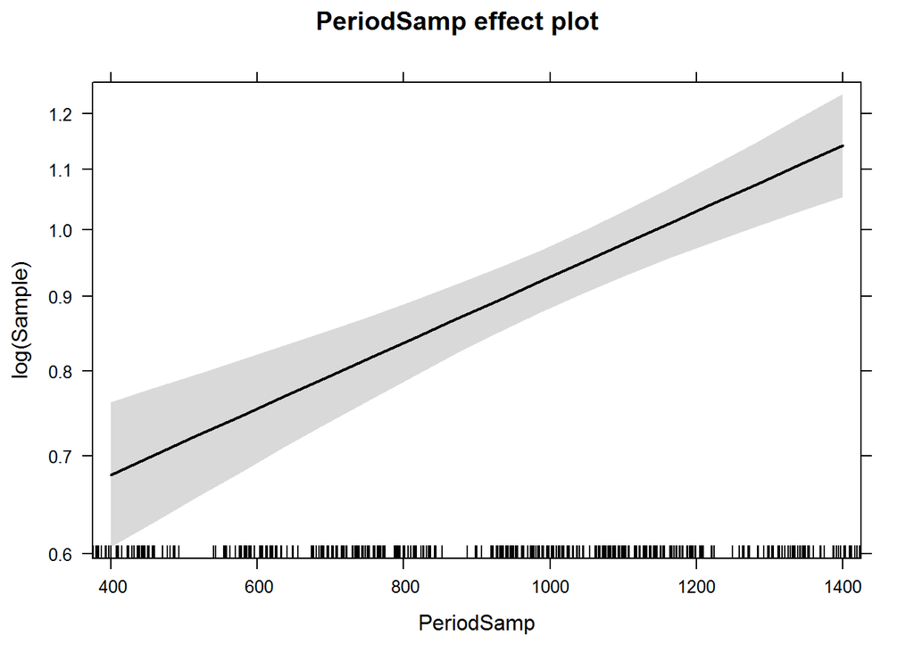

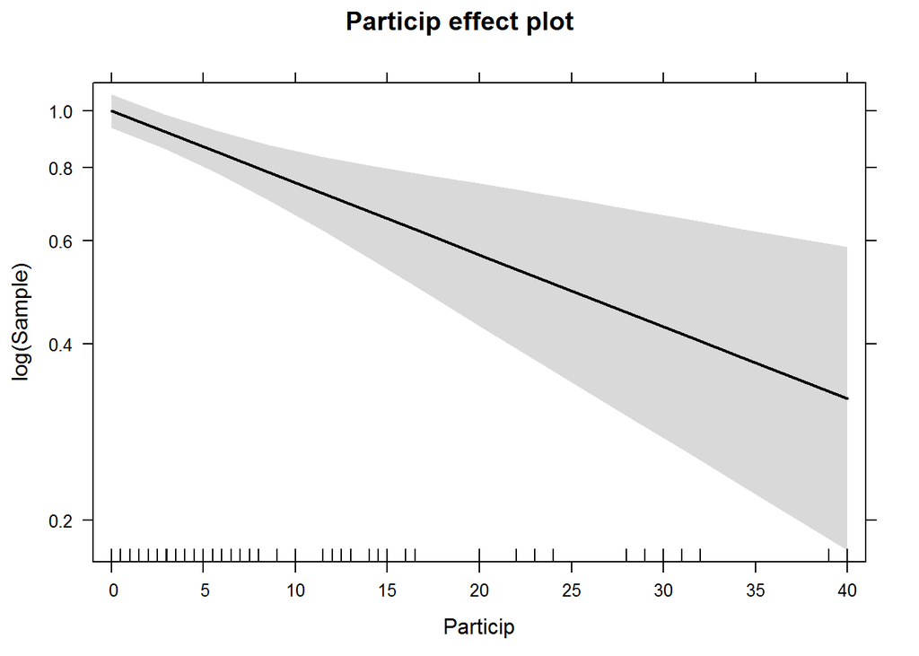

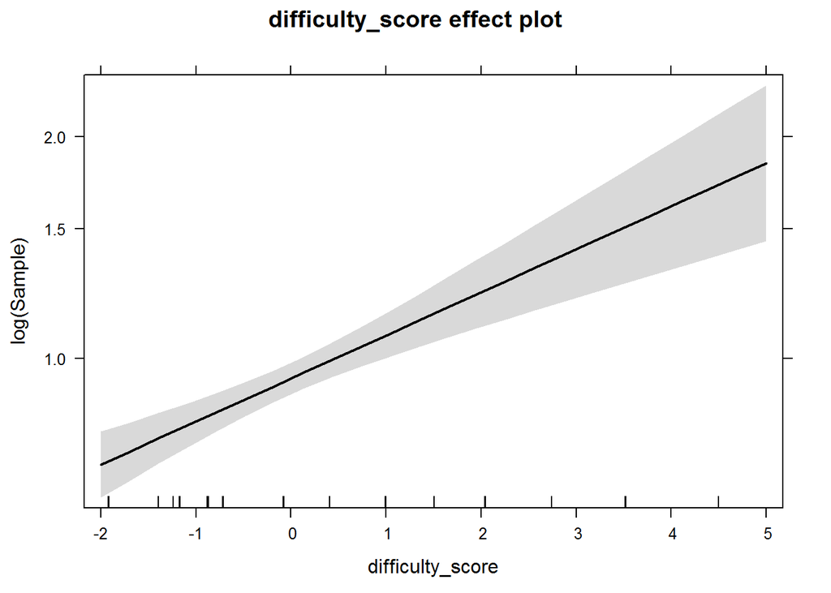

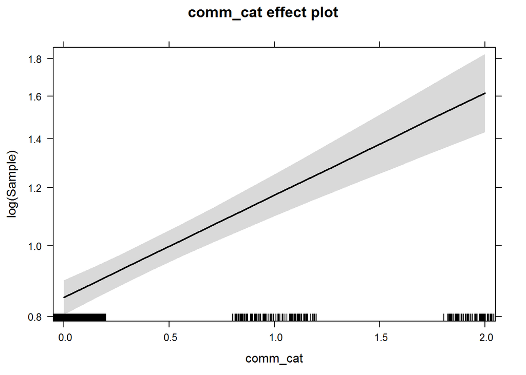

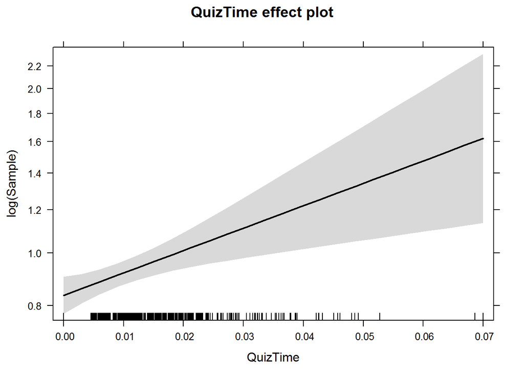

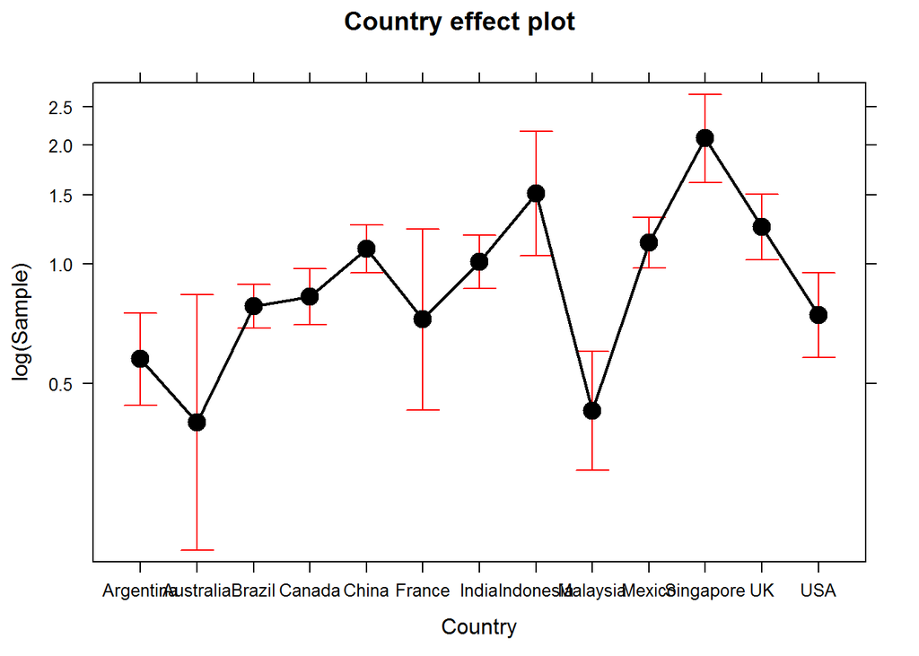

```r
# Let's plot the significant results.
# The y-axis can be viewed as the increase in number of samples
for(i in c('PeriodSamp','Particip','difficulty_score','comm_cat','QuizTime','Country')){
  print(plot(Effect(i, m2a)))
}
```

# Training retention model

We know that a lot of people who do the training do not go on to submit any records. Why is the case? are there some attibutes of the training that these people undertake, or the people themselves, which predicts retention? Here we use a binomial modelt to see which variables predict retention (0/1 - did they submit 0 records/did they submit >0 records). There is a 6 month period from the last training event to the date of data extraction, we consider this to be a long enough period for our binomial response to be accurate.

## Data

```r
# The data we want is the same as above but we want to keep people with 0 records
str(clean_data)
```

```
## 'data.frame':    7413 obs. of  63 variables:
##  $ uid             : int  3549 3550 3551 3552 3553 3554 3555 3557 444 3558 ...
##  $ Date            : Date, format: "2012-09-10" "2012-09-10" ...
##  $ Code            : chr  "London41191" "London41191" "London41191" "London41191" ...
##  $ Protocol        : chr  "London" "London" "London" "London" ...
##  $ Country         : Factor w/ 13 levels "Argentina","Australia",..: 12 12 12 12 12 12 12 12 12 12 ...
##  $ TrainTeam       : int  8 11 8 8 8 8 8 8 11 11 ...
##  $ Rainfall        : num  0.055 0.055 0.055 0.055 0.055 ...
##  $ Temp            : num  10.6 10.6 10.6 10.6 10.6 ...
##  $ Paid            : int  1 1 1 1 1 1 1 1 1 1 ...
##  $ Team            : int  0 0 0 0 0 0 0 0 0 0 ...
##  $ Self            : int  1 1 1 1 1 1 1 1 1 1 ...
##  $ People          : num  1 1 1 1 1 1 1 1 1 1 ...
##  $ Assign          : int  0 0 0 0 0 0 0 0 0 0 ...
##  $ TranTrai        : int  0 0 0 0 0 0 0 0 0 0 ...
```

[output cut: 49 more lines]

```r
# Let's create our binary column
clean_data$Sample01 <- ifelse(clean_data$Sample > 0, 1, 0)

# Lets veiw the metrics we are going to use
summary(clean_data[,c('Paid','TranTrai','Upload','TrainTeam','TeamPoints','Team','Temp','Rainfall', 'People')])
```

```
##       Paid           TranTrai          Upload         TrainTeam
##  Min.   :0.0000   Min.   :0.0000   Min.   :0.0000   Min.   : 3.00
##  1st Qu.:0.0000   1st Qu.:0.0000   1st Qu.:0.0000   1st Qu.:17.00
##  Median :0.0000   Median :1.0000   Median :1.0000   Median :21.00
##  Mean   :0.4106   Mean   :0.5357   Mean   :0.6762   Mean   :21.84
##  3rd Qu.:1.0000   3rd Qu.:1.0000   3rd Qu.:1.0000   3rd Qu.:26.00
##  Max.   :1.0000   Max.   :1.0000   Max.   :1.0000   Max.   :62.00
##    TeamPoints           Team            Temp           Rainfall
##  Min.   :0.00000   Min.   :0.000   Min.   :-17.59   Min.   :0.000000
##  1st Qu.:0.00000   1st Qu.:1.000   1st Qu.: 16.16   1st Qu.:0.000000
##  Median :0.03791   Median :1.000   Median : 21.95   Median :0.002169
##  Mean   :0.07712   Mean   :0.811   Mean   : 19.99   Mean   :0.144138
##  3rd Qu.:0.08537   3rd Qu.:1.000   3rd Qu.: 25.10   3rd Qu.:0.186201
##  Max.   :1.57072   Max.   :1.000   Max.   : 34.31   Max.   :3.168762
##      People
##  Min.   : 0.000
##  1st Qu.: 2.500
##  Median : 4.000
##  Mean   : 4.106
##  3rd Qu.: 5.000
##  Max.   :10.000
```

```r
cor(clean_data[,c('Paid','TranTrai','Upload','TrainTeam','TeamPoints','Team','Temp','Rainfall', 'People')])
```

```
##                   Paid    TranTrai      Upload  TrainTeam  TeamPoints
## Paid        1.00000000 -0.30988833 -0.27631018 -0.1511607 -0.02821448
## TranTrai   -0.30988833  1.00000000 -0.06611250  0.2971244 -0.01523401
## Upload     -0.27631018 -0.06611250  1.00000000  0.0287112  0.07977613
## TrainTeam  -0.15116071  0.29712439  0.02871120  1.0000000 -0.13469230
## TeamPoints -0.02821448 -0.01523401  0.07977613 -0.1346923  1.00000000
## Team       -0.44665640  0.51850637 -0.21030089  0.3887212  0.01158401
## Temp       -0.33741554  0.38731757  0.04853447  0.2829360 -0.07537576
## Rainfall   -0.07069624  0.17381481  0.01384590  0.1247864  0.03371305
## People     -0.22971778  0.66965731 -0.32072542  0.3956317 -0.16162247
##                   Team        Temp    Rainfall     People
## Paid       -0.44665640 -0.33741554 -0.07069624 -0.2297178
## TranTrai    0.51850637  0.38731757  0.17381481  0.6696573
## Upload     -0.21030089  0.04853447  0.01384590 -0.3207254
## TrainTeam   0.38872124  0.28293604  0.12478645  0.3956317
## TeamPoints  0.01158401 -0.07537576  0.03371305 -0.1616225
## Team        1.00000000  0.44946258  0.04889314  0.6151893
## Temp        0.44946258  1.00000000  0.13325769  0.3630752
## Rainfall    0.04889314  0.13325769  1.00000000  0.1582454
## People      0.61518930  0.36307522  0.15824536  1.0000000
```

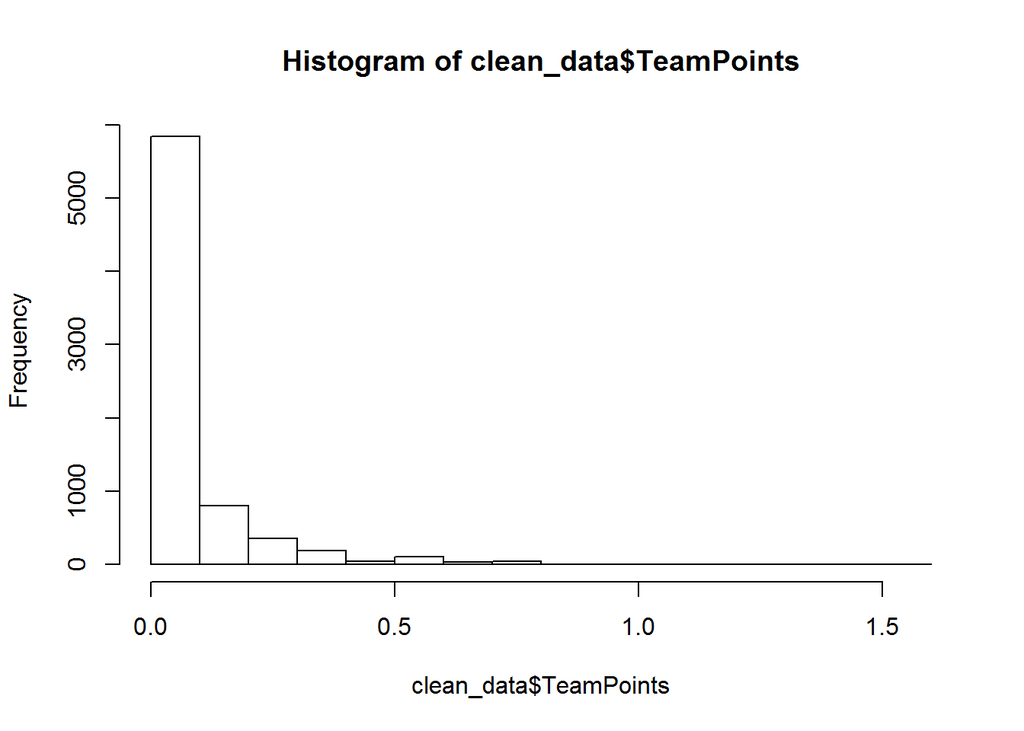

```r
# Take a look at some of these
hist(clean_data$TeamPoints)
```

```r
# A lot of people attend training where nobody has submitted any records
sum(clean_data$TeamPoints == 0)
```

```
## [1] 2656
```

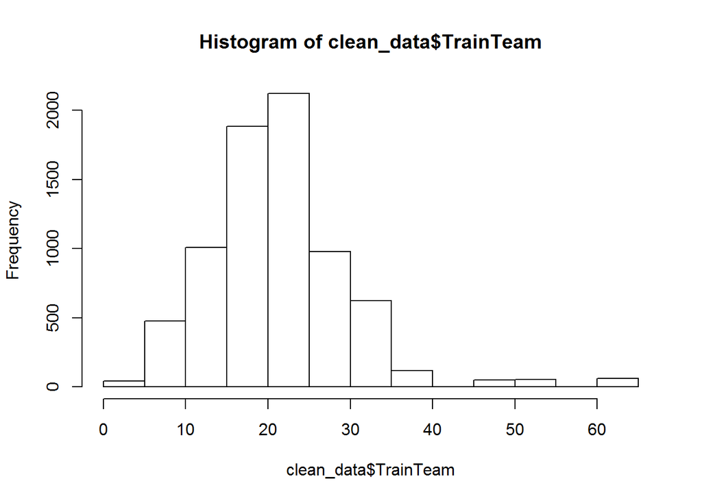

```r
hist(clean_data$TrainTeam)
```

Now lets do some modelling

```r
b1 <- glm(Sample01 ~ Paid +
                     TranTrai +
                     Upload +
                     TrainTeam +
                     log(TeamPoints+0.001) +
                     Team +
                     Temp +
                     Rainfall,
          family = binomial(link = "logit"),
          data = clean_data)
# plot(b1, ask = FALSE)
summary(b1)
```

```
##
## Call:
## glm(formula = Sample01 ~ Paid + TranTrai + Upload + TrainTeam +
##     log(TeamPoints + 0.001) + Team + Temp + Rainfall, family = binomial(link = "logit"),
##     data = clean_data)
##
## Deviance Residuals:
##     Min       1Q   Median       3Q      Max
## -1.3908  -0.7114  -0.5013  -0.2944   2.6162
##
## Coefficients:
##                          Estimate Std. Error z value Pr(>|z|)
## (Intercept)             -0.070914   0.165405  -0.429   0.6681
## Paid                    -0.327749   0.082470  -3.974 7.06e-05 ***
## TranTrai                -0.140340   0.071874  -1.953   0.0509 .
## Upload                   0.513171   0.079432   6.461 1.04e-10 ***
## TrainTeam               -0.028709   0.004544  -6.318 2.65e-10 ***
## log(TeamPoints + 0.001)  0.341972   0.016123  21.210  < 2e-16 ***
## Team                     1.066148   0.120139   8.874  < 2e-16 ***
## Temp                    -0.023140   0.005142  -4.501 6.78e-06 ***
## Rainfall                -0.147608   0.104828  -1.408   0.1591
## ---
## Signif. codes:  0 '***' 0.001 '**' 0.01 '*' 0.05 '.' 0.1 ' ' 1
##
## (Dispersion parameter for binomial family taken to be 1)
##
##     Null deviance: 7494.3  on 7412  degrees of freedom
## Residual deviance: 6700.1  on 7404  degrees of freedom
## AIC: 6718.1
##
## Number of Fisher Scoring iterations: 5
```

```r
step(b1)
```

```
## Start:  AIC=6718.06
## Sample01 ~ Paid + TranTrai + Upload + TrainTeam + log(TeamPoints +
##     0.001) + Team + Temp + Rainfall
##
##                           Df Deviance    AIC
## <none>                         6700.1 6718.1
## - Rainfall                 1   6702.1 6718.1
## - TranTrai                 1   6703.9 6719.9
## - Paid                     1   6715.9 6731.9
## - Temp                     1   6719.9 6735.9
## - TrainTeam                1   6742.2 6758.2
## - Upload                   1   6743.7 6759.7
## - Team                     1   6783.3 6799.3
## - log(TeamPoints + 0.001)  1   7232.5 7248.5
```

```
##
## Call:  glm(formula = Sample01 ~ Paid + TranTrai + Upload + TrainTeam +
##     log(TeamPoints + 0.001) + Team + Temp + Rainfall, family = binomial(link = "logit"),
##     data = clean_data)
##
## Coefficients:
##             (Intercept)                     Paid                 TranTrai
##                -0.07091                 -0.32775                 -0.14034
##                  Upload                TrainTeam  log(TeamPoints + 0.001)
##                 0.51317                 -0.02871                  0.34197
##                    Team                     Temp                 Rainfall
##                 1.06615                 -0.02314                 -0.14761
##
## Degrees of Freedom: 7412 Total (i.e. Null);  7404 Residual
## Null Deviance:       7494
## Residual Deviance: 6700  AIC: 6718
```

```r
deviance_explained <- (b1$null.deviance - b1$deviance) / b1$null.deviance
deviance_explained
```

```
## [1] 0.1059803
```

```r
# Colinarity does not seem to be a big issue
car::vif(b1)
```

```
##                    Paid                TranTrai                  Upload
##                1.682619                1.385540                1.383808
##               TrainTeam log(TeamPoints + 0.001)                    Team
##                1.277963                1.032476                2.075385
##                    Temp                Rainfall
##                1.405124                1.061694
```